# Replication of Task Kepler

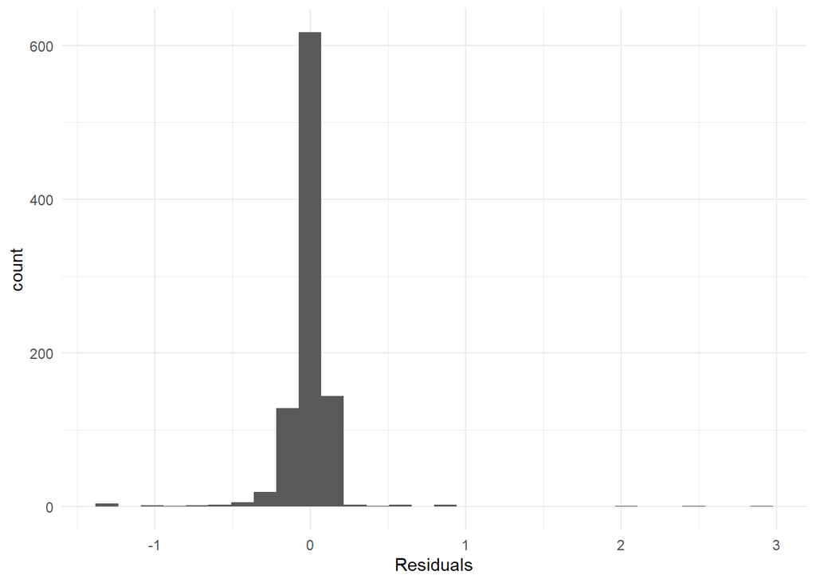

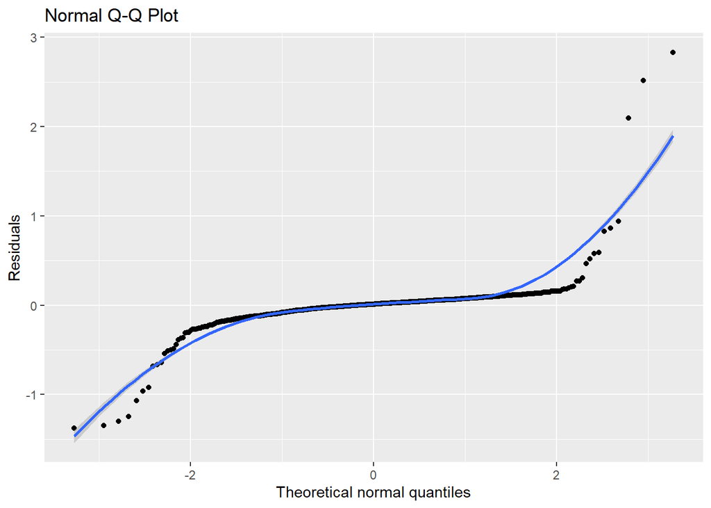

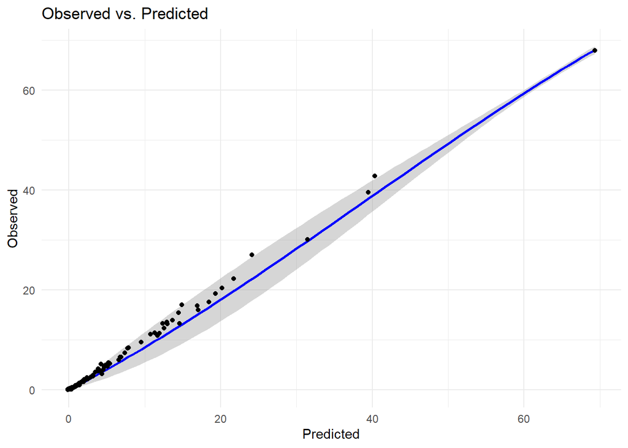

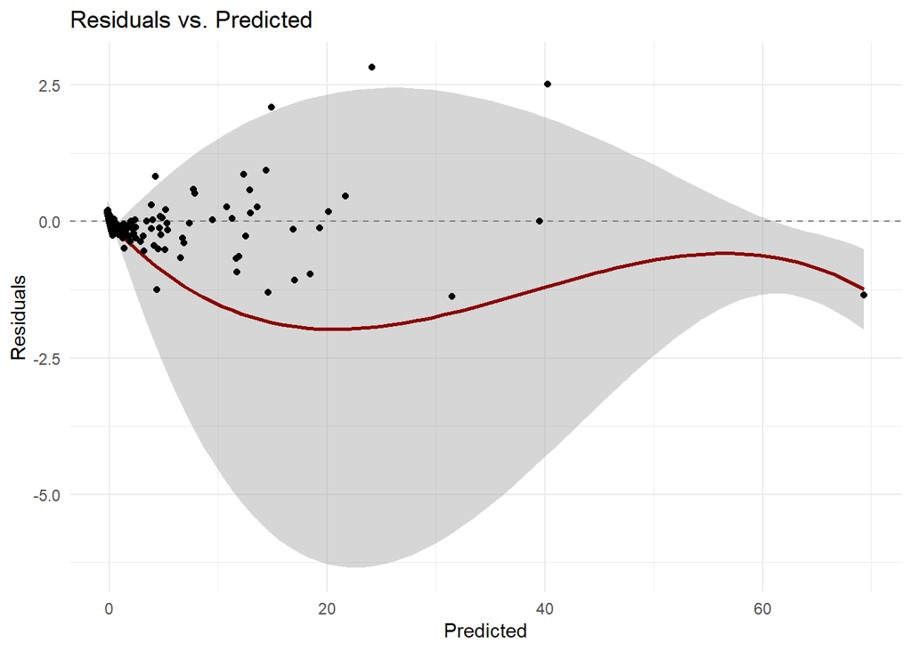

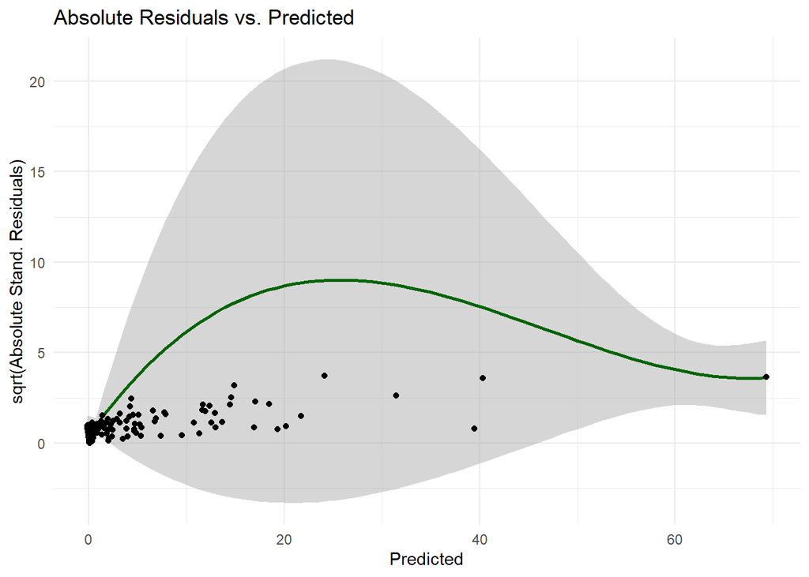

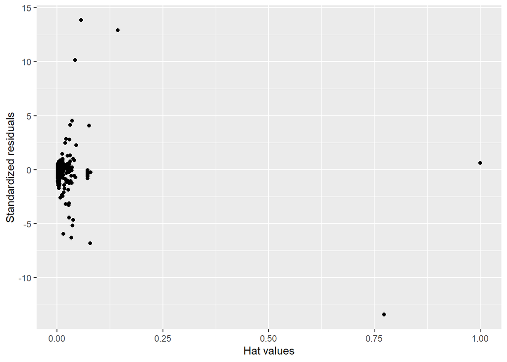

```r
plot_lm_diagnostics(fits[[7]])
```

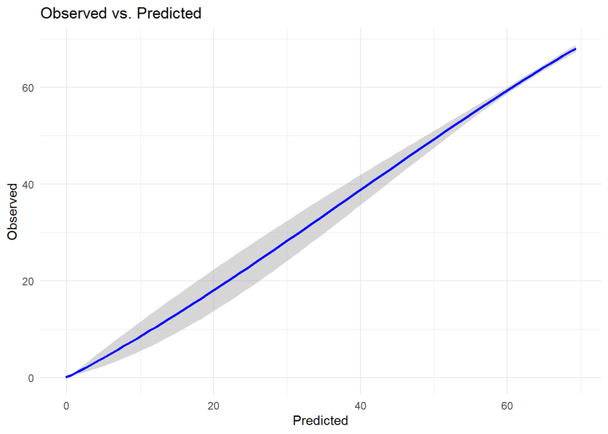

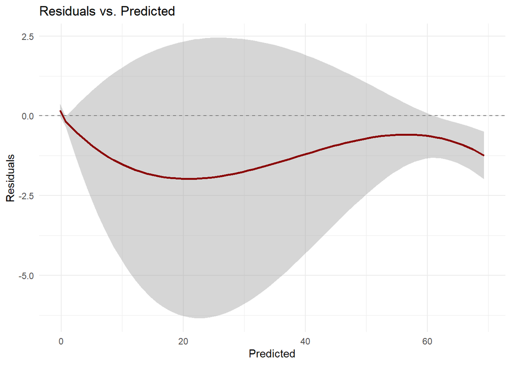

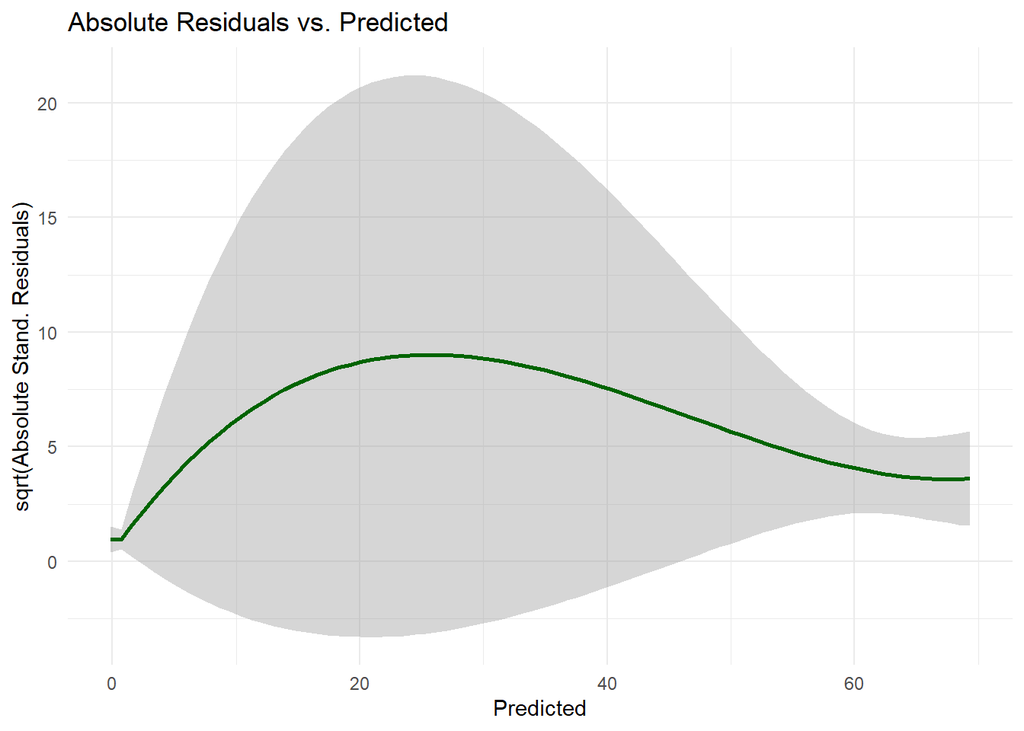

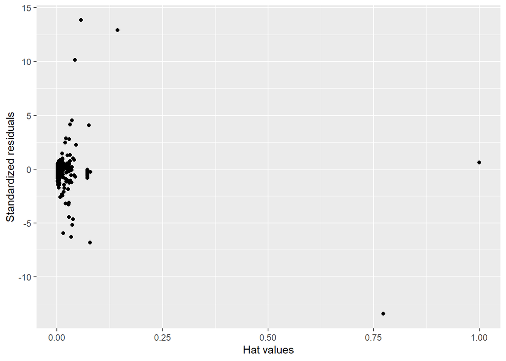

```r
plot_lm_diagnostics(fits[[7]], point=FALSE, hist=FALSE)
```

The residual plots indicate that the model is probably not correctly specified, and that there are some highly influential data foints.

We repeat the analysis without the two data points that were identified already earlier.

```r
ss_ymfp_rob <- matrix(0,length(out_trans), 3)  # 3 columns: SS, df of model, BIC
colnames(ss_ymfp_rob) <- c("SumSq", "DF", "BIC")

fits_rob <- vector(mode="list", length = length(out_trans))
pred_ymfp_rob <- matrix(0, nrow(analysis_rob), length(out_trans))
mape_rob <- vector(mode="numeric", length(length(out_trans)))


# loop over outcome transformations
for(j in 1:length(out_trans)){
  # transform outcome
  y_tmp <- FPY(analysis_rob$semimajoraxis, out_trans[j])
  # fit MFP model with transformed outcome
  fit_tmp <-    mfp2(data=analysis_rob, y_tmp ~ fp(hoststar_mass) + fp(period) + fp(mass) + fp(hoststar_temperature) + fp(radius) + fp(eccentricity) + fp(hoststar_radius) + fp(hoststar_metallicity) + binaryflag, df=4, criterion="bic", verbose=FALSE)
  fits_rob[[j]] <- fit_tmp
  # evaluate sum of squares with inversely transformed linear predictor
  pred_ymfp_rob[,j] <- IFPY(predict(fit_tmp, newdata=analysis_rob), out_trans[j])
  ss_ymfp_rob[j,1] <- sum((pred_ymfp_rob[,j] - analysis_rob$semimajoraxis)^2)
  ss_ymfp_rob[j,2] <- sum(fit_tmp$fp_terms[,"df_final"])
  ss_ymfp_rob[j,3] <- ss_ymfp_rob[j,1] + log(fit_tmp$df.null+1) * ss_ymfp_rob[j,2]   # bic
  mape_rob[j] <- median(abs(analysis_rob$semimajoraxis - pred_ymfp_rob[,j]))
}


# evaluate results
round(cbind(out_trans, ss_ymfp_rob),1)
```

```
     out_trans   SumSq DF     BIC
[1,]      -1.0 12208.8 10 12277.2
[2,]      -0.5 17290.9 12 17373.0
[3,]      -0.3  3325.8 15  3428.4
[4,]       0.0     0.3  4    27.7
[5,]       0.3   279.0 12   361.1
[6,]       0.5    56.9 10   125.3
[7,]       1.0    32.3 12   114.4
```

```r
cbind(out_trans, mape_rob)
```

```
      out_trans     mape_rob
[1,] -1.0000000 0.0020834709
[2,] -0.5000000 0.0012705961
[3,] -0.3333333 0.0018440153
[4,]  0.0000000 0.0001273616
[5,]  0.3333333 0.0059137134
[6,]  0.5000000 0.0070587393
[7,]  1.0000000 0.0362017708
```

Using the reduced data set, the optimal model is again exactly the Kepler model.

```r
fits_rob[[4]]
```

```
Shifting, Scaling and Centering of covariates
                        shift scale center
period               0.000000 10000   TRUE
eccentricity         0.129317     1   TRUE
mass                 0.000000    10   TRUE
radius               0.000000     1   TRUE
hoststar_mass        0.000000     1   TRUE
binaryflag           0.000000     1   TRUE
hoststar_metallicity 0.920000     1   TRUE
hoststar_temperature 0.000000  1000   TRUE
hoststar_radius      0.000000    10   TRUE

Final Multivariable Fractional Polynomial for y
                     df_initial select alpha selected df_final power1
period                        4    BIC   BIC     TRUE        2      0
eccentricity                  4    BIC   BIC    FALSE        0     NA
mass                          4    BIC   BIC    FALSE        0     NA
radius                        4    BIC   BIC    FALSE        0     NA
hoststar_mass                 4    BIC   BIC     TRUE        2      0
binaryflag                    1    BIC   BIC    FALSE        0     NA
hoststar_metallicity          4    BIC   BIC    FALSE        0     NA
hoststar_temperature          4    BIC   BIC    FALSE        0     NA
hoststar_radius               4    BIC   BIC    FALSE        0     NA

MFP algorithm convergence: TRUE

Call:  glm(formula = y ~ ., family = family, data = data, weights = weights,
    offset = offset, x = TRUE, y = TRUE)

Coefficients:
    (Intercept)         period.1  hoststar_mass.1
        -2.3555           0.6668           0.3322

Degrees of Freedom: 936 Total (i.e. Null);  934 Residual
Null Deviance:      1850
Residual Deviance: 2.047    AIC: -3073
```

This model identifies period and hoststar_mass as the two influential variables:

```r
beta_std(fits_rob[[4]], analysis_rob)
```

```
              period        hoststar_mass         eccentricity
           1.3915260            0.1272911            0.0000000
                mass               radius           binaryflag
           0.0000000            0.0000000            0.0000000
hoststar_metallicity hoststar_temperature      hoststar_radius
           0.0000000            0.0000000            0.0000000
```

The following plots the log(BIC) vs. the outcome transformation:

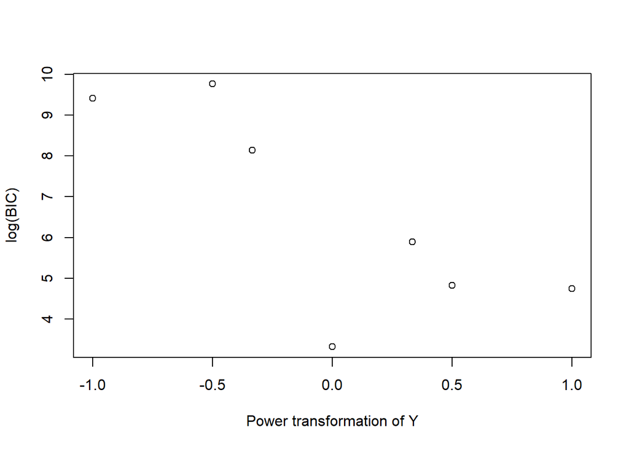

```r
plot(out_trans, log(ss_ymfp_rob[,3]), ylab="log(BIC)", xlab="Power transformation of Y")
```

The residual diagnostics for the optimal model:

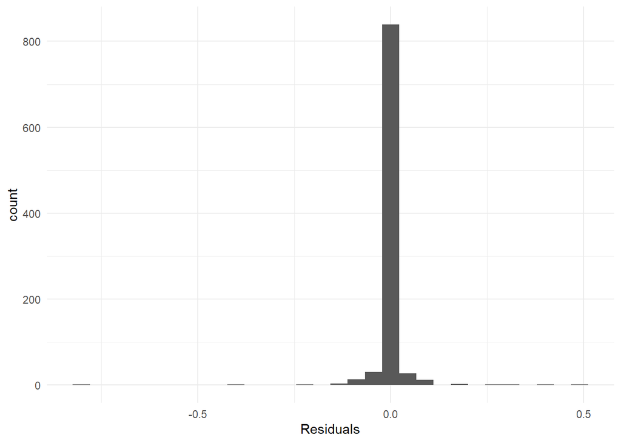

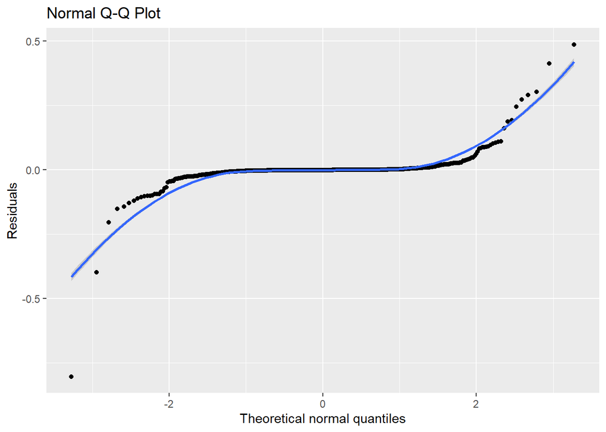

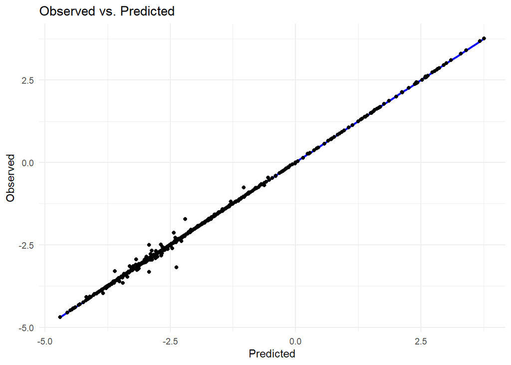

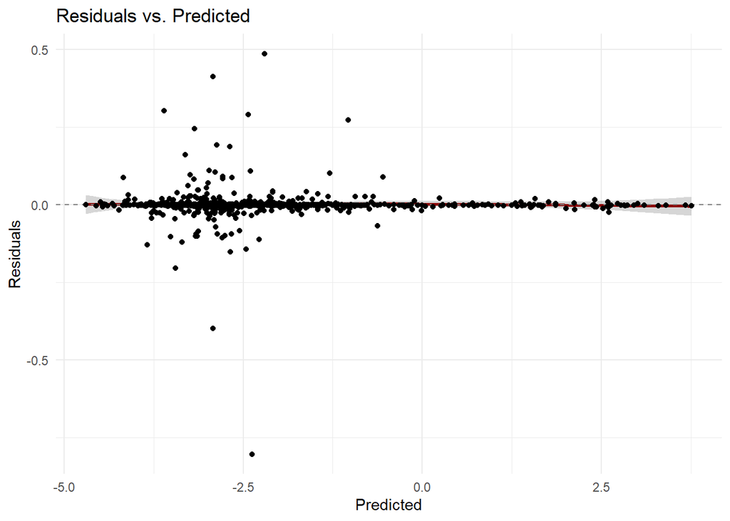

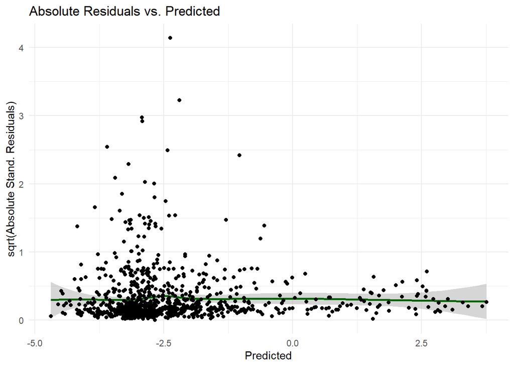

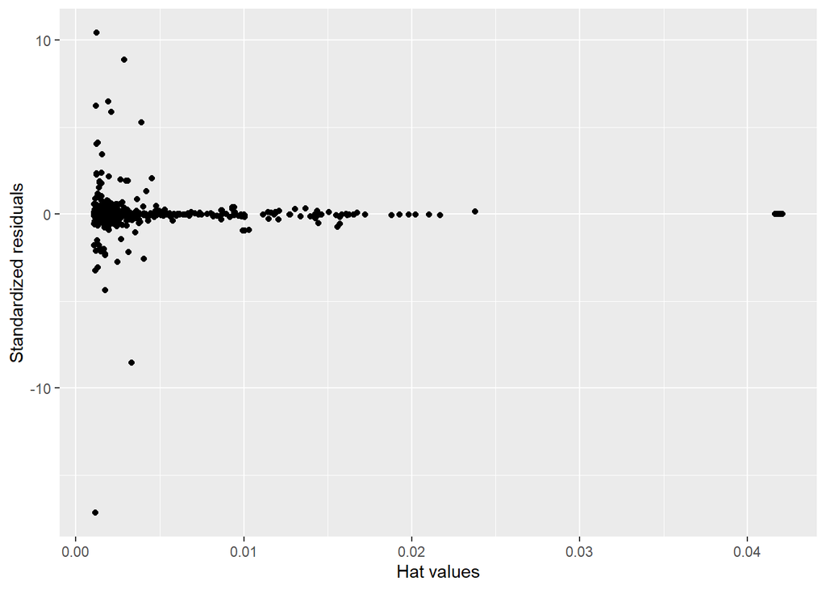

```r
plot_lm_diagnostics(fits_rob[[4]])
```

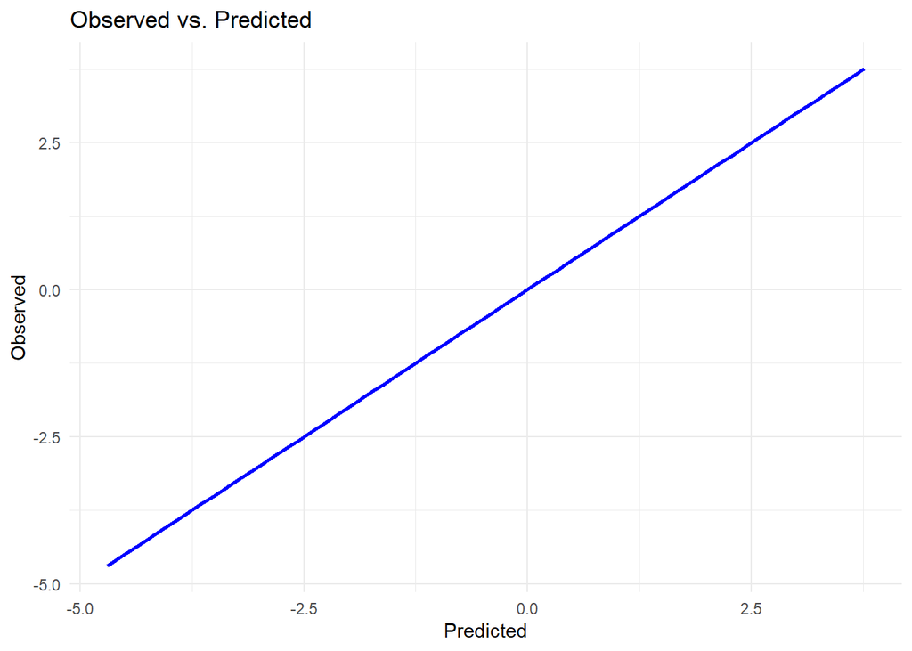

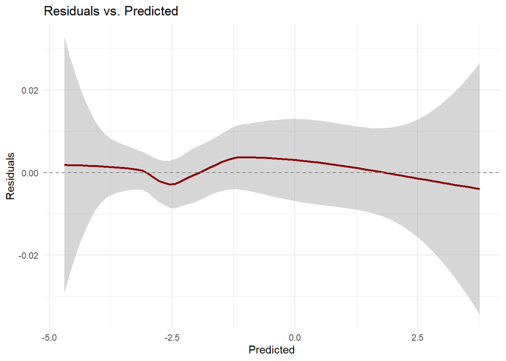

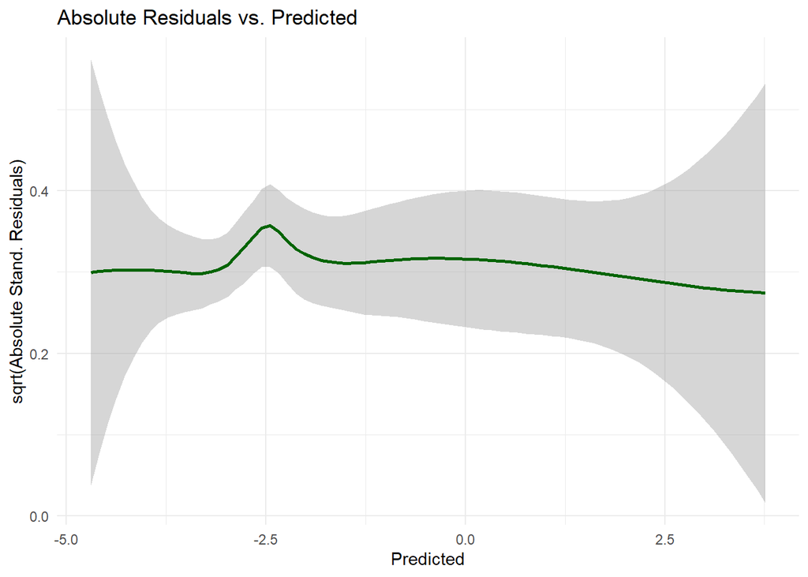

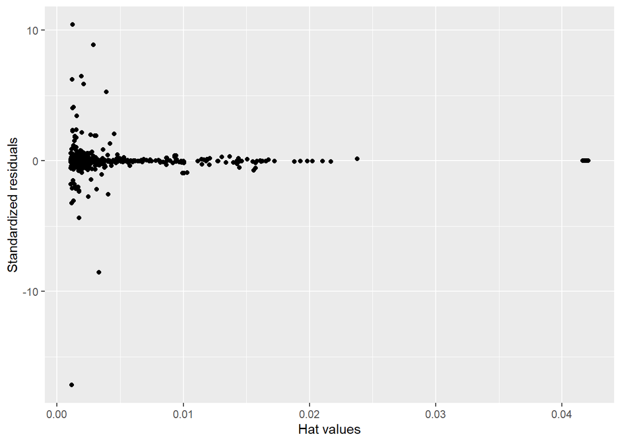

```r
plot_lm_diagnostics(fits_rob[[4]], point=FALSE, hist=FALSE)
```

The residual plots do not indicate any major concerns.

The following two plots depict the estimated functional forms (recall that the outcome was log-transformed):

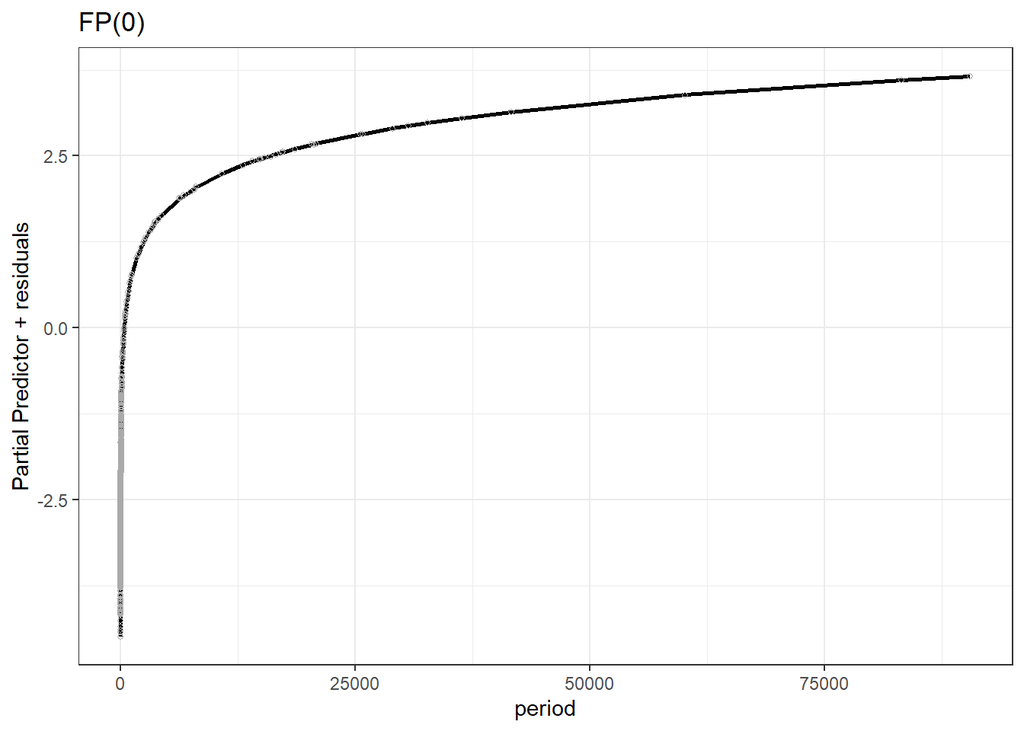

```r
fracplot(fits_rob[[4]], terms ="period")
```

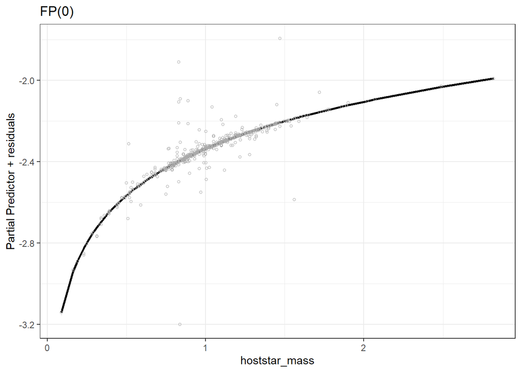

```r
fracplot(fits_rob[[4]], terms ="hoststar_mass")
```

Because of the high $R^2$, we skip the internal validation by cross-validation.

In the following, we conduct a bootstrap analysis with 50 iterations to investigate if the identified model is stable. This analysis is based on the data set with the two influential observations removed.

```r
# bootstrap analysis to investigate model stability
if(do_bootstrap) {
  B <- 50
  best_out_trans <- 0*(1:B)
  best_fp_terms1 <- matrix(NA, B, 9)
  colnames(best_fp_terms1) <- varlist[-1]
  best_fp_terms2 <- matrix(NA, B, 9)
  colnames(best_fp_terms2) <- varlist[-1]
  partial_b <- vector(mode = "list", length=B)

  set.seed(7123981)
  for(b in 1:B){
    analysis_brob <- analysis_rob[sample(1:nrow(analysis_rob), repl=TRUE),]

    fits_brob <- vector(mode="list", length = length(out_trans))
    bic_tmp <- vector(mode="numeric", length = length(out_trans))

    # loop over outcome transformations
    for(j in 1:length(out_trans)){
      # transform outcome
      y_tmp <- FPY(analysis_brob$semimajoraxis, out_trans[j])
      # fit MFP model with transformed outcome
      fit_tmp <-    mfp2(data=analysis_brob, y_tmp ~ fp(hoststar_mass) + fp(period) + fp(mass) + fp(hoststar_temperature) + fp(radius) + fp(eccentricity) + fp(hoststar_radius) + fp(hoststar_metallicity) + binaryflag, df=4, criterion="bic", verbose=FALSE, cycles=10)
      fits_brob[[j]] <- fit_tmp
      # evaluate sum of squares with inversely transformed linear predictor
      pred_tmp <- IFPY(predict(fit_tmp, newdata=analysis_brob), out_trans[j])
      ss_tmp <- sum((pred_tmp - analysis_brob$semimajoraxis)^2)
      df_tmp <- sum(fit_tmp$fp_terms[,"df_final"])
      bic_tmp[j] <- ss_tmp + log(fit_tmp$df.null+1) * df_tmp   # bic

    }

    best_out_trans[b] <- out_trans[which.min(bic_tmp)]
    #cat("Resample ", b, " Best outcome transformation: ", best_out_trans[b], "\n")
    best_fp_terms1[b,] <- fits_brob[[which.min(bic_tmp)]]$fp_terms[colnames(best_fp_terms1),"power1"]
    if(any(fits_brob[[which.min(bic_tmp)]]$fp_terms[, "df_final"] == 4)) best_fp_terms2[b, ] <- fits_brob[[which.min(bic_tmp)]]$fp_terms[colnames(best_fp_terms1),"power2"]
    # save partial fits for best fit for spaghetti plot
    partial_b[[b]] <- partial(fits_brob[[which.min(bic_tmp)]], analysis_rob, median)

  }

  table(best_out_trans)
} else {
  load("bootstrap_results.Rdata")
}
```

In all resamples, the optimal outcome transformation according to BIC on the original scale was the log transformation.

```r
period_fp <- sapply(1:B, function(X) paste(best_fp_terms1[X,"period"], best_fp_terms2[X,"period"]))
table(period_fp)
```

```
period_fp
0 NA
  50
```

```r
hoststar_mass_fp <- sapply(1:B, function(X) paste(best_fp_terms1[X,"hoststar_mass"], best_fp_terms2[X,"hoststar_mass"]))
table(hoststar_mass_fp)
```

```
hoststar_mass_fp
-2 -0.5     0 3    0 NA  0.5 NA    1 NA
      1       1      37       6       5
```

```r
mass_fp <- sapply(1:B, function(X) paste(best_fp_terms1[X,"mass"], best_fp_terms2[X,"mass"]))
table(mass_fp)
```

```
mass_fp
 0 NA NA NA
    1    49
```

```r
hoststar_temperature_fp <- sapply(1:B, function(X) paste(best_fp_terms1[X,"hoststar_temperature"], best_fp_terms2[X,"hoststar_temperature"]))
table(hoststar_temperature_fp)
```

```
hoststar_temperature_fp
-2 NA  1 NA NA NA
    2     9    39
```

We finally list the frequencies of the selected outcome transformations and the frequencies of the selected FPs.

### Variability of estimated functional forms

Based on the bootstrap, we can plot the estimated functional forms for each variable.

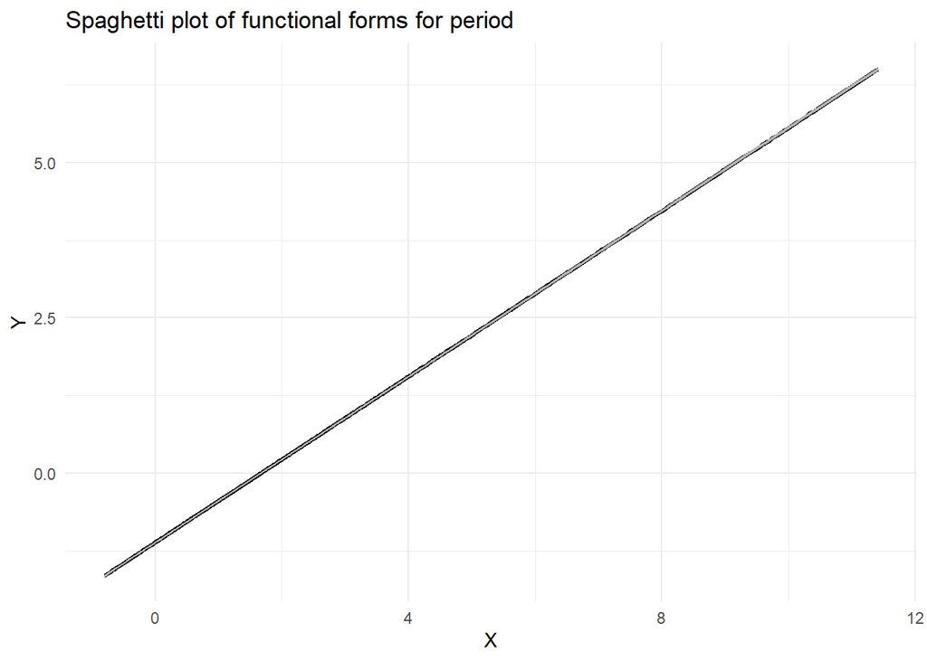

```r
# arrange results into a matrix

partial_fits <- partial(fits_rob[[4]], analysis_rob, median)

period_ff <- matrix(sapply(1:B, function(X) partial_b[[X]][,"period"]), nrow(analysis_rob), B, byrow=FALSE)

hoststar_mass_ff <- matrix(sapply(1:B, function(X) partial_b[[X]][,"hoststar_mass"]), nrow(analysis_rob), B, byrow=FALSE)

mass_ff <- matrix(sapply(1:B, function(X) partial_b[[X]][,"mass"]), nrow(analysis_rob), B, byrow=FALSE)


spaghetti_plot(x = log(analysis_rob[,"period"]), y_main=partial_fits[,"period"], y_mat = period_ff) + ggtitle("Spaghetti plot of functional forms for period")
```

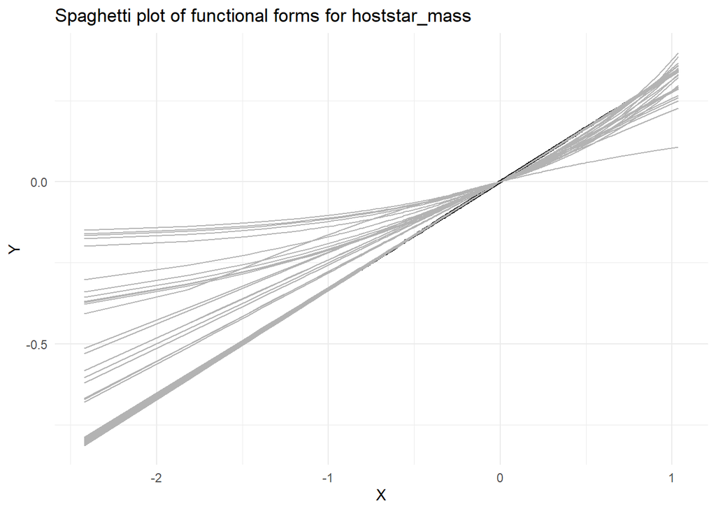

```r
spaghetti_plot(x = log(analysis_rob[,"hoststar_mass"]), y_main=partial_fits[,"hoststar_mass"], y_mat = hoststar_mass_ff) + ggtitle("Spaghetti plot of functional forms for hoststar_mass")
```

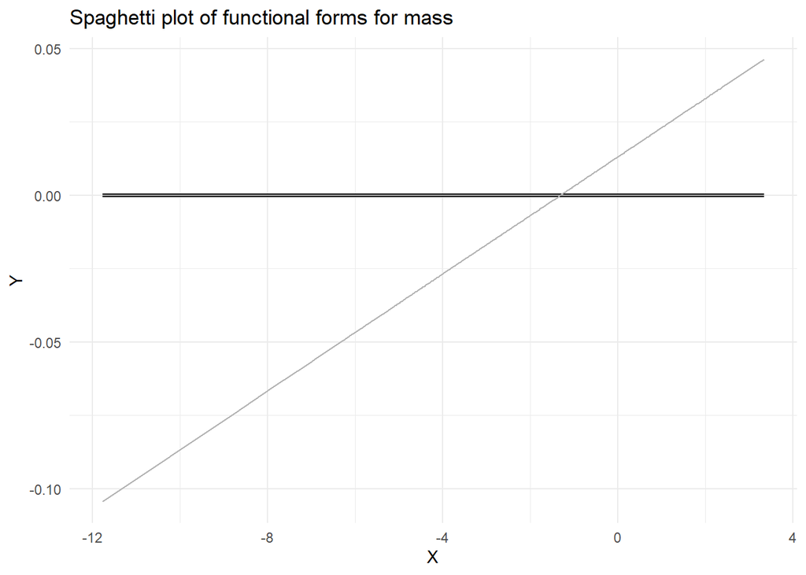

```r
spaghetti_plot(x = log(analysis_rob[,"mass"]), y_main=partial_fits[,"mass"], y_mat = mass_ff) + ggtitle("Spaghetti plot of functional forms for mass")
```

### Model 5: Generalized additive model with restricted cubic splines with 3 df

#### Analysis

We apply the splines model to the log-transformed data set.

```r
# MVRS using RCS with 3df

source("mvrs.R")

analysis_log$binaryflag <- as.factor(analysis_log$binaryflag)
fit_mvrs <- mvrs_glm(data = analysis_log, formula=formula, mode_cont = "310", crit_all="bic", family="gaussian")
```

```
Detected variables:
...Factors:  binaryflag
...Continuous:  mass radius period eccentricity hoststar_mass hoststar_radius hoststar_metallicity hoststar_temperature
...knots 3df:  function (X)  quantile(X, c(0.05, 0.33, 0.67, 0.95))
... ... mass : -5.04 -3.34 -0.28 1.77
... ... radius : -2.22 -1.29 0.11 0.46
... ... period : 0.35 1.34 2.41 7.56
... ... eccentricity : -2.04 -2.04 -1.62 -0.59
... ... hoststar_mass : -0.7 -0.12 0.1 0.38
... ... hoststar_radius : -0.73 -0.14 0.23 0.72
... ... hoststar_metallicity : -0.39 -0.01 0.13 0.29
... ... hoststar_temperature : 8.2 8.58 8.68 8.77
Visiting sequence:  period hoststar_mass hoststar_radius hoststar_metallicity hoststar_temperature mass eccentricity radius binaryflag
Iteration  1
...Variable  period
... ...NS3 vs NULL:  delta BIC = -6173.251
... ...NS3 vs Linear:  delta BIC = 12.863
...Variable  hoststar_mass
... ...NS3 vs NULL:  delta BIC = -320.524
... ...NS3 vs Linear:  delta BIC = 6.207
...Variable  hoststar_radius
... ...NS3 vs NULL:  delta BIC = 7.873
...Variable  hoststar_metallicity
... ...NS3 vs NULL:  delta BIC = 7.455
...Variable  hoststar_temperature
... ...NS3 vs NULL:  delta BIC = 16.436
...Variable  mass
... ...NS3 vs NULL:  delta BIC = 18.453
...Variable  eccentricity
... ...NS3 vs NULL:  delta BIC = 13.196
...Variable  radius
... ...NS3 vs NULL:  delta BIC = 19.771
...Variable  binaryflag
... ...Include vs exclude:  delta BIC = 6.777
Iteration  2
...Variable  period
... ...NS3 vs NULL:  delta BIC = -6369.9
... ...NS3 vs Linear:  delta BIC = 13.016
...Variable  hoststar_mass
... ...NS3 vs NULL:  delta BIC = -1977.007
... ...NS3 vs Linear:  delta BIC = 13.307
...Variable  hoststar_radius
... ...NS3 vs NULL:  delta BIC = 11.501
...Variable  hoststar_metallicity
... ...NS3 vs NULL:  delta BIC = 8.255
...Variable  hoststar_temperature
... ...NS3 vs NULL:  delta BIC = 16.411
...Variable  mass
... ...NS3 vs NULL:  delta BIC = 19.173
...Variable  eccentricity
... ...NS3 vs NULL:  delta BIC = 13.326
...Variable  radius
... ...NS3 vs NULL:  delta BIC = 19.816
...Variable  binaryflag
... ...Include vs exclude:  delta BIC = 6.777
Converged after  2  cycles.
Final terms:
 period
hoststar_mass
```

```r
drop1(fit_mvrs$model)
```

```
Single term deletions

Model:
semimajoraxis ~ period + hoststar_mass
              Df Deviance     AIC
<none>               2.05 -3081.5
period         1  1847.54  3306.3
hoststar_mass  1    17.18 -1086.3
```

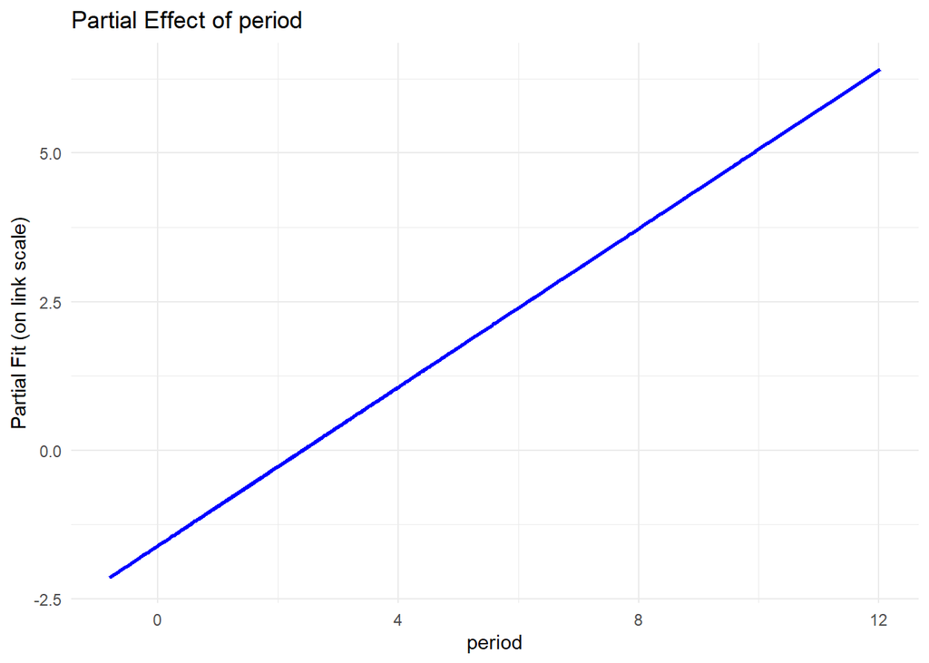

```r
#termplot(fit_mvrs$model)

p_terms <-  predict(fit_mvrs$model, type="terms", se=T, newdata=analysis_log)
#pred_mvrs <- fit_mvrs$model$fitted.values
#res_mvrs <- fit_mvrs$model$residuals

plot_glm_term(p_terms, term_name = "period",  data = analysis_log)
```

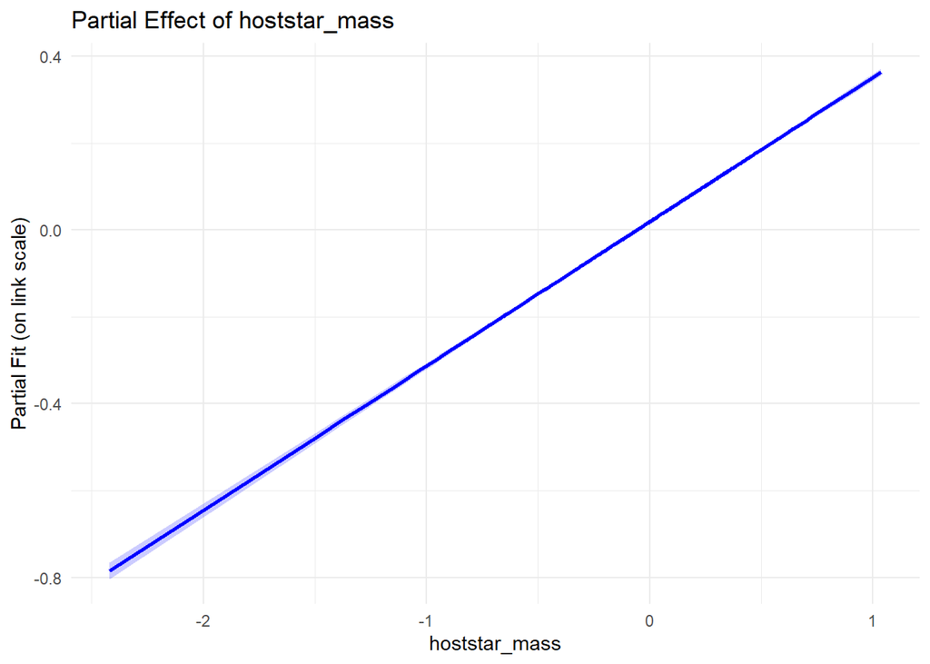

```r
plot_glm_term(p_terms, term_name = "hoststar_mass", data = analysis_log)
```

```r
plot_lm_diagnostics(fit_mvrs$model)
```

[output not shown]

Again, this analysis yields the Kepler model.

The next model forces the splines into the model:

```r
fit_mvrsf <- mvrs_glm(data = analysis_log, formula, mode_cont = "310", crit_select="bic", crit_fsp = "significance", sl_fsp=1, family="gaussian")
```

```
Detected variables:
...Factors:  binaryflag
...Continuous:  mass radius period eccentricity hoststar_mass hoststar_radius hoststar_metallicity hoststar_temperature
...knots 3df:  function (X)  quantile(X, c(0.05, 0.33, 0.67, 0.95))
... ... mass : -5.04 -3.34 -0.28 1.77
... ... radius : -2.22 -1.29 0.11 0.46
... ... period : 0.35 1.34 2.41 7.56
... ... eccentricity : -2.04 -2.04 -1.62 -0.59
... ... hoststar_mass : -0.7 -0.12 0.1 0.38
... ... hoststar_radius : -0.73 -0.14 0.23 0.72
... ... hoststar_metallicity : -0.39 -0.01 0.13 0.29
... ... hoststar_temperature : 8.2 8.58 8.68 8.77
Visiting sequence:  period hoststar_mass hoststar_radius hoststar_metallicity hoststar_temperature mass eccentricity radius binaryflag
Iteration  1
...Variable  period
... ...NS3 vs NULL:  delta BIC = -6173.251
... ...NS3 vs Linear:  p-value = 0.665
...Variable  hoststar_mass
... ...NS3 vs NULL:  delta BIC = -320.03
... ...NS3 vs Linear:  p-value = 0.029
...Variable  hoststar_radius
... ...NS3 vs NULL:  delta BIC = 0.929
...Variable  hoststar_metallicity
... ...NS3 vs NULL:  delta BIC = 7.638
...Variable  hoststar_temperature
... ...NS3 vs NULL:  delta BIC = 15.687
...Variable  mass
... ...NS3 vs NULL:  delta BIC = 18.898
...Variable  eccentricity
... ...NS3 vs NULL:  delta BIC = 13.187
...Variable  radius
... ...NS3 vs NULL:  delta BIC = 18.813
...Variable  binaryflag
... ...Include vs exclude:  delta BIC = 6.789
Iteration  2
...Variable  period
... ...NS3 vs NULL:  delta BIC = -6369.565
... ...NS3 vs Linear:  p-value = 0.757
...Variable  hoststar_mass
... ...NS3 vs NULL:  delta BIC = -1968.193
... ...NS3 vs Linear:  p-value = 0.875
...Variable  hoststar_radius
... ...NS3 vs NULL:  delta BIC = 0.287
...Variable  hoststar_metallicity
... ...NS3 vs NULL:  delta BIC = 8.422
...Variable  hoststar_temperature
... ...NS3 vs NULL:  delta BIC = 15.385
...Variable  mass
... ...NS3 vs NULL:  delta BIC = 18.848
...Variable  eccentricity
... ...NS3 vs NULL:  delta BIC = 13.405
...Variable  radius
... ...NS3 vs NULL:  delta BIC = 18.879
...Variable  binaryflag
... ...Include vs exclude:  delta BIC = 6.789
Converged after  2  cycles.
Final terms:
 ns(period, knots=c(1.34,2.41), Boundary.knots=c(0.35,7.56))
ns(hoststar_mass, knots=c(-0.12,0.1), Boundary.knots=c(-0.7,0.38))
```

```r
drop1(fit_mvrsf$model)
```

```
Single term deletions

Model:
semimajoraxis ~ ns(period, knots = c(1.34, 2.41), Boundary.knots = c(0.35,
    7.56)) + ns(hoststar_mass, knots = c(-0.12, 0.1), Boundary.knots = c(-0.7,
    0.38))
                                                                         Df
<none>
ns(period, knots = c(1.34, 2.41), Boundary.knots = c(0.35, 7.56))         3
ns(hoststar_mass, knots = c(-0.12, 0.1), Boundary.knots = c(-0.7, 0.38))  3
                                                                         Deviance
<none>                                                                       2.05
ns(period, knots = c(1.34, 2.41), Boundary.knots = c(0.35, 7.56))         1846.36
ns(hoststar_mass, knots = c(-0.12, 0.1), Boundary.knots = c(-0.7, 0.38))    17.01
                                                                             AIC
<none>                                                                   -3074.4
ns(period, knots = c(1.34, 2.41), Boundary.knots = c(0.35, 7.56))         3309.7
ns(hoststar_mass, knots = c(-0.12, 0.1), Boundary.knots = c(-0.7, 0.38)) -1091.7
```

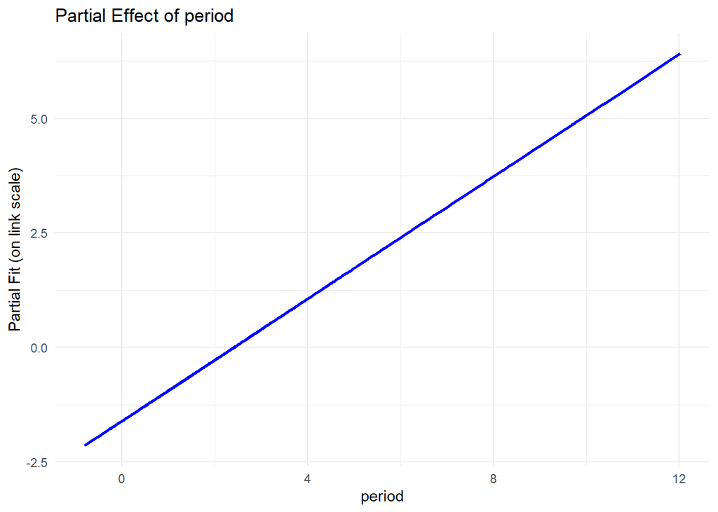

```r
p_termsf <-  predict(fit_mvrsf$model, type="terms", se=T, newdata=analysis_log)

## for some reasons I get a strange error here, replaced by termplot
plot_glm_term(p_termsf, term_name = "period",  data = analysis_log)
```

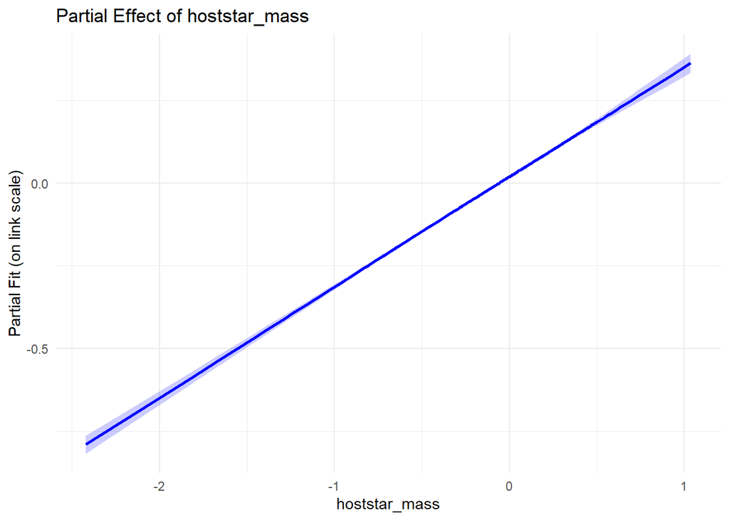

```r
plot_glm_term(p_termsf, term_name = "hoststar_mass", data = analysis_log)
```

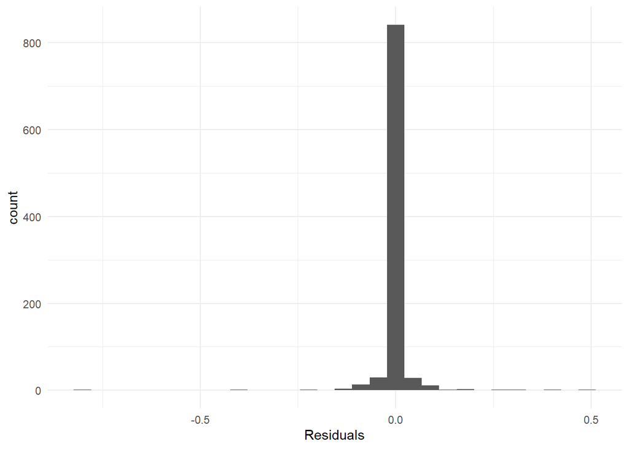

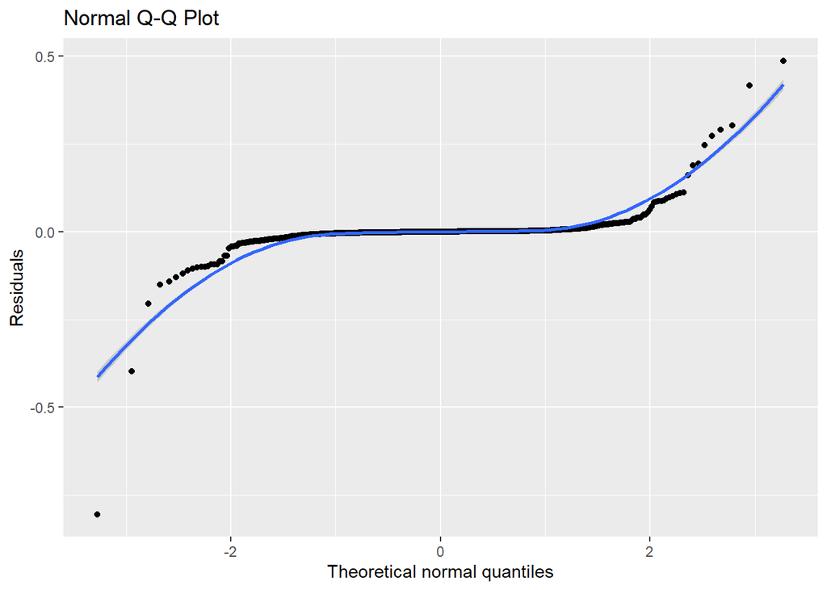

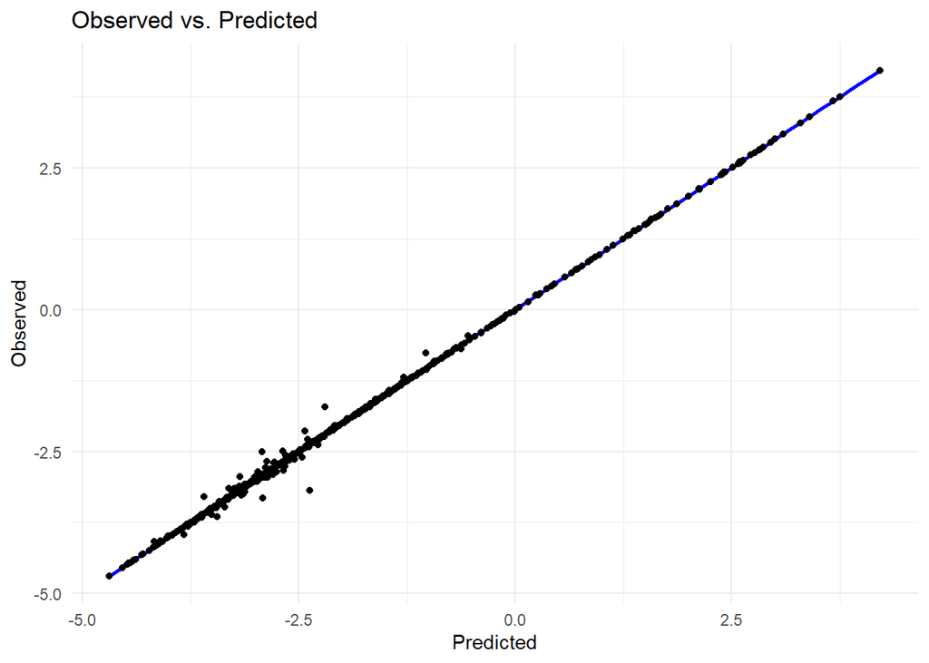

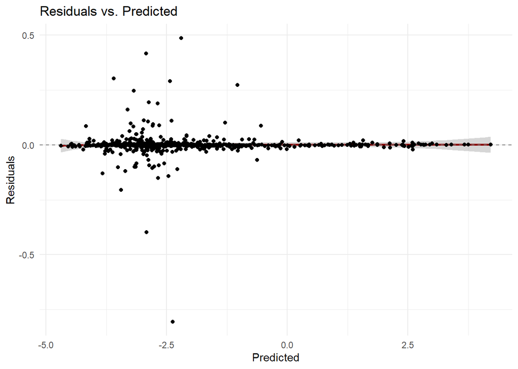

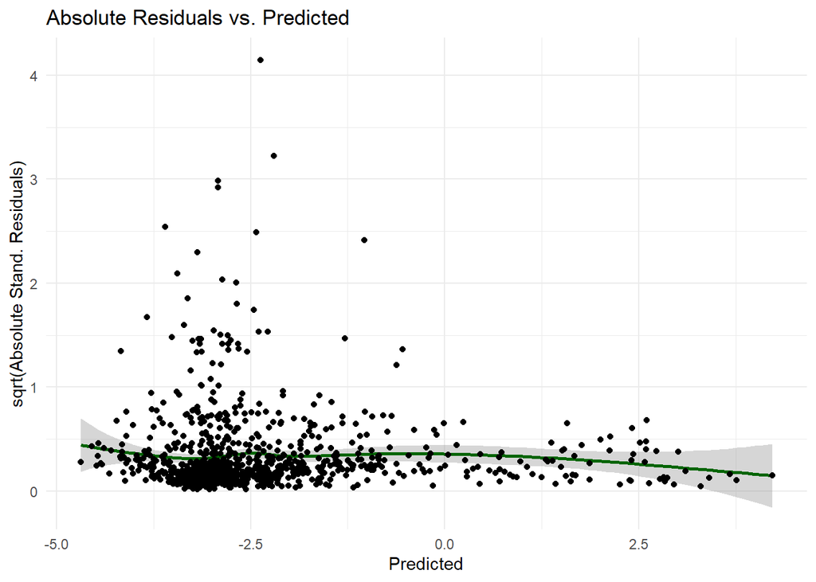

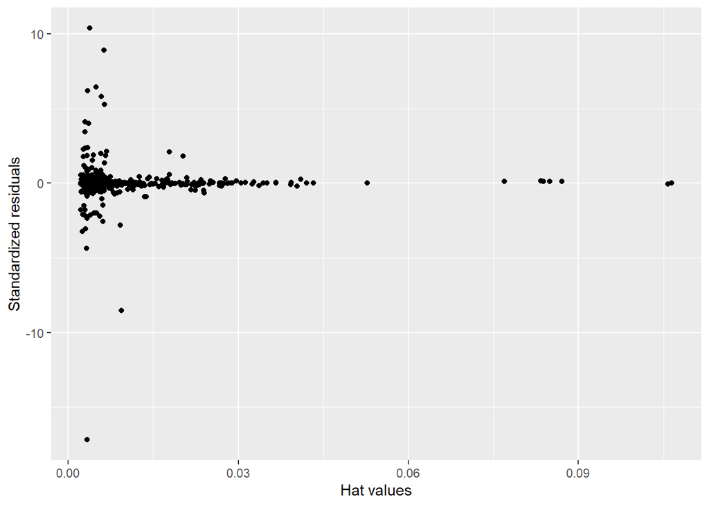

```r
#termplot(fit_mvrsf$model, rug=TRUE, se=TRUE)

plot_lm_diagnostics(fit_mvrsf$model)
```

## Summary

The analysis based on the formula semimajoraxis ~ mass + radius + period + eccentricity + hoststar_mass + hoststar_radius + hoststar_metallicity + hoststar_temperature + binaryflag, allowing for nonlinear functional forms for the continuous predictors, converges to the Kepler model. Instead of the symbolic regression model, a outcome-transforming MFP model was estimated which also converges to the Kepler model. This was then assessed for stability, which revealed that for hoststar_mass there was some variation, but the model was stable for period. Also with the multivariable regression splines (MVRS) strategy, the model was stably detected. Even if splines were forced into the model, the estimated associations with the log outcome look linear with minimally increased variation compared to a forced-linear model.